# Análisis del uso de sistemas de inteligencia artificial en la mejora del rendimiento académico en estudiantes de la UTEC

30 Agosto, 2023

# Relevancia:

- **¿Es el estudio de interés para la audiencia?**  
  Los sistemas de inteligencia artificial (IA) se han convertido en una herramienta importante para el aprendizaje y la mejora del rendimiento académico en los estudiantes universitarios. Con el uso de tecnologías de IA, los estudiantes pueden obtener retroalimentación inmediata y personalizada sobre su desempeño, lo que puede ayudarles a identificar áreas de mejora y optimizar su tiempo de estudio o en otros casos simplemente facilitarles el trabajo. Este informe tiene como principal objetivo analizar el uso de sistemas de IA académicos y su impacto en el rendimiento académico de los estudiantes universitarios.
- **¿Cuáles son los objetivos del estudio?**.
- A pesar de que se ha vuelto a hacer popular la Inteligencia Artificial, no muchas personas conocen esta tecnología y tampoco su potencial. Es por eso que nuestros objetivos son los siguientes:  
  1.- Investigar los motivos por los cuales los estudiantes de la UTEC utilizan sistemas de inteligencia artificial en el ámbito académico.  
  2.- Evaluar la efectividad del uso de sistemas de inteligencia artificial en la mejora del rendimiento académico de los estudiantes de la UTEC.  
  3.- Determinar el perfil de estudiante UTEC que usa IA’s para ser apoyados en el ámbito académico.

### Contexto:

En la actualidad se puede presenciar que las IA’s se han vuelto muy famosas, lo que conlleva que estas herramientas puedan dividir opiniones de diversas personas que la utilicen, algunos pueden creer que puede generar dependencia o creen que llegan a prescindir la idea de lograr un objetivo por cuenta propia. Estás dicotomías serán utilizadas en base a un sector pequeño, en este caso se utilizará la opinión de estudiantes de la universidad de tecnología e ingeniería UTEC. En específico se tomará en cuenta la relación de opiniones respecto al ámbito de *estudio*.

# Datos:

## Proceso de recolección de datos:

Los datos se recopilaron a través de encuestas en línea a una muestra aleatoria de la UTEC. La encuesta incluyó preguntas sobre el uso de los sistemas de IA, la frecuencia de uso y la percepción de su impacto en el rendimiento académico. De igual forma, se realizaron preguntas desde las más básicas como “¿Qué es una inteligencia artificial?” hasta algunas más críticas como “¿Te preocupa su avance?”.

[figure not shown]

## Población, muestra y muestreo

### Población

La población a la que querremos entrevistar será a los estudiantes universitarios de la universidad UTEC. Con esto nos referimos a estudiantes de cualquier carrera y sin importar el ciclo en el que estén, es decir que será un tipo de muestra aleatoria.

### Muestra

El tamaño de la muestra es de 186 alumnos, lo que sugiere que es una muestra representativa, que permitirá trabajar y lograr el análisis de estos datos.

### Muestreo

Nosotros diríamos que es un muestreo estratificado ya que son grupos disjuntos homogéneos:

1. Grupos de diferentes ciclos pero misma universidad.
2. Gupos de diferentes carreras pero misma universidad
3. Grupos de diferentes cursos pero misma carrera.

Es por eso que planeamos utilizar un muestreo que garantize una distribución equilibrada de estudiantes de diferentes niveles académicos y carreras.

## Variables de Estudio

### 1) Numéricas (8)

#### Discreta (5)

| Pregunta | Variable | **Restricción |
| --- | --- | --- |
| ¿Cuál es su edad? | Edad | Entero positivo |
| ¿Cuál consideras qué es tu nivel de conocimiento sobre la IA? | Nivel de conocimiento | Número del 1 al 10 |
| ¿Cuál consideras qué es tu nivel de conocimiento sobre la IA? | Beneficios | Número del 1 al 10 |
| ¿Qué opinas sobre la interacción entre humanos y la IA, en la actualidad? | Opinión | Número del 1 al 10 |
| ¿Cuántos años crees que pasarán antes de que la inteligencia artificial tenga un auge aún mayor que el actual? | Años para auge | Intervalo de valores entre el 1 al 50 |

#### Continua (3)

| Pregunta | Variable | **Restricción |
| --- | --- | --- |
| En tu uso cotidiano de IAs,¿ cuánto consideras que te proporciona una respuesta útil? (En porcentaje) | Porcentaje de uso | Valor entre el 0 al 100% |
| ¿Cuánto tiempo sientes que ahorras usando inteligencia artificial para tus actividades? | Tiempo ahorrado | Valor entre el 1 a 10 horas |
| ¿Cuánto crees que abarque las IAs con respectos a todos los empleos en general? | Opinión | Valor entre el 0 al 100% |

#### Ordinal (13)

| Pregunta | Variable | **Restricción |
| --- | --- | --- |
| ¿En qué ciclo de estudio se encuentra? | Ciclo | Número del 1 al 10 |
| ¿Has utilizado la IA antes? | Utilización | Frecuentemente, a veces, nunca |
| ¿Cuál es tu actitud hacia la IA? | Actitud | Positiva, negativa, neutral |
| ¿En qué nivel de confianza clasificarías la IA? | Nivel de confianza | Pregunta cerrada |
| ¿Crees que la regulación de la IA es necesaria? | Opinión | Pregunta cerrada (Sí o No) |
| ¿En qué nivel de optimismo clasificarías el futuro de la IA? | Optimismo | Muy pesimista, pesimista, neutral, optimista, muy optimista |
| ¿Crees que la inteligencia artificial tendrá un impacto significativo en tu futura profesión o campo de estudio? | Suposiciones | Sí, tal vez, no lo se |
| ¿Te gustaría aprender más sobre inteligencia artificial y cómo se aplica en la vida cotidiana, en tu campo de estudio o en tu futura profesión? | Gustos | Sí, no, tal vez |
| ¿Estarías dispuesto/a a estudiar algo relacionado con la tecnología para mantener tus habilidades actualizadas y no quedarte sin trabajo? | Estudio | Sí, tal vez, no |
| ¿Crees que la inteligencia artificial tiene el potencial de desplazar trabajos humanos a gran escala en el futuro? | Opinión | Sí, no, tal vez |
| ¿Crees que en el futuro las personas podrían confiar en la inteligencia artificial como un recurso para el asesoramiento y apoyo psicológico? | Nivel de confianza | Pregunta cerrada: Sí, No |
| ¿Crees que la inteligencia artificial podría desarrollar su propia conciencia o “autoconciencia” en el futuro? | Opinión | Pregunta cerrada: Sí, No |
| ¿Crees que la inteligencia artificial podría tener la capacidad de reemplazar la creatividad y la originalidad humanas en áreas como el arte, la literatura o la música? | Opinión | Pregunta cerrada: Sí, No |

#### Nominal (7)

| Pregunta | Variable | **Restricción |
| --- | --- | --- |
| ¿Cuál es su género? | Género | Pregunta cerrada |
| ¿Qué carrera estudias? | Carrera | Pregunta cerrada |
| ¿Conoces alguna inteligencia artificial? | Conocimiento | Pregunta cerrada (Sí o No) |
| ¿Cuáles son tus principales preocupaciones acerca de la IA? | Preocupaciones | Pregunta cerrada |
| ¿Cuál de las siguientes áreas crees que se beneficiará más con el avance de la inteligencia artificial en el futuro? | Opinión | Opción múltiple de áreas laborales |
| ¿Qué inteligencias artificiales conoces? | Conocimiento | Opción múltiple |
| ¿Crees que la creciente dependencia de la inteligencia artificial podría afectar la capacidad de las personas para ejercer un juicio crítico independiente? | Opinión | Pregunta cerrada: Sí, No |

# Limpieza de datos de Base_de_datos.csv:

```r
Base_de_datos<-read_csv('Base_de_datos.csv')
```

- No se encontraron datos exagerados o fuera de nuestros parámetros, por lo que no se tuvo demasiado problema limpiando variables que afectaran o generaran alguna tendencia en nuestros resultados.

## 1. Cambio de tipo de variable:

```r
Base_de_datos$`¿Cuál es tu edad?` <- as.integer(Base_de_datos$`¿Cuál es tu edad?`)
Base_de_datos$`¿En qué ciclo se encuentra?` <- as.integer(Base_de_datos$`¿En qué ciclo se encuentra?`)

Base_de_datos$`¿Qué tan beneficiosos consideras que son los sistemas de IA? (1= Nada beneficioso 10= Extremadamente beneficioso)` <- as.integer(Base_de_datos$`¿Qué tan beneficiosos consideras que son los sistemas de IA? (1= Nada beneficioso 10= Extremadamente beneficioso)`)

Base_de_datos$`En tu uso cotidiano de IAs, ¿Cuánto consideras que te proporciona resultados útiles?. (1= Nada útil 10= Extremadamente útil ; Si no usas sistemas de IA pon "0")` <- as.integer(Base_de_datos$`En tu uso cotidiano de IAs, ¿Cuánto consideras que te proporciona resultados útiles?. (1= Nada útil 10= Extremadamente útil ; Si no usas sistemas de IA pon "0")`)

Base_de_datos$`Del 1 al 10 ¿Cuánto tiempo sientes que ahorras usando inteligencia artificial para tus actividades? (1= Nada de tiempo 10= Demasiado Tiempo; Si no usas sistemas de IA pon "0")` <- as.integer(Base_de_datos$`Del 1 al 10 ¿Cuánto tiempo sientes que ahorras usando inteligencia artificial para tus actividades? (1= Nada de tiempo 10= Demasiado Tiempo; Si no usas sistemas de IA pon "0")`)

Base_de_datos$`Escribe tu promedio ponderado del ciclo 2022-2`<-as.numeric(Base_de_datos$`Escribe tu promedio ponderado del ciclo 2022-2`)
```

## 2. Moderamiento de respuestas:

### Analizamos las respuestas de la pregunta “¿Cuáles son tus principales preocupaciones acerca de la IA?” y llevamos a cabo un moderamiento de datos buscando patrones parecidos entre las respuestas y generando una sola respuesta igual para todas las parecidas.

```r
patron<-"\\ b(depend|acostu|acad|usando|domin)\\w\\b"
Base_de_datos$`¿Cuáles son tus principales preocupaciones acerca de la IA?`<-ifelse(grepl(patron,Base_de_datos$`¿Cuáles son tus principales preocupaciones acerca de la IA?`),"Dependencia de las personas en las IAs", Base_de_datos$`¿Cuáles son tus principales preocupaciones acerca de la IA?`)
Base_de_datos$`¿Cuáles son tus principales preocupaciones acerca de la IA?` <- gsub("\\b.*(depen|acostum|domin|tiempo que paso|costum|utilizarlo dema).*\\b", "Dependencia de las personas en las IAs", Base_de_datos$`¿Cuáles son tus principales preocupaciones acerca de la IA?`,ignore.case = TRUE)
Base_de_datos$`¿Cuáles son tus principales preocupaciones acerca de la IA?` <- gsub("\\b.*(Ninguna|ninguna).*\\b", "No tengo preocupaciones", Base_de_datos$`¿Cuáles son tus principales preocupaciones acerca de la IA?`,ignore.case = TRUE)
Base_de_datos$`¿Cuáles son tus principales preocupaciones acerca de la IA?` <- gsub("\\b.*nada.*\\b", "No tengo preocupaciones", Base_de_datos$`¿Cuáles son tus principales preocupaciones acerca de la IA?`,ignore.case = TRUE)
Base_de_datos$`¿Cuáles son tus principales preocupaciones acerca de la IA?` <- gsub("\\b.*---.*\\b", "No tengo preocupaciones", Base_de_datos$`¿Cuáles son tus principales preocupaciones acerca de la IA?`,ignore.case = TRUE)
Base_de_datos$`¿Cuáles son tus principales preocupaciones acerca de la IA?` <- gsub("\\b.*reemp.*\\b", "Reemplazar a las personas laboralmente", Base_de_datos$`¿Cuáles son tus principales preocupaciones acerca de la IA?`,ignore.case = TRUE)
Base_de_datos$`¿Cuáles son tus principales preocupaciones acerca de la IA?` <- gsub("\\b.*quit.*\\b", "Reemplazar a las personas laboralmente", Base_de_datos$`¿Cuáles son tus principales preocupaciones acerca de la IA?`,ignore.case = TRUE)
Base_de_datos$`¿Cuáles son tus principales preocupaciones acerca de la IA?` <- gsub("\\b.*suplan.*\\b", "Reemplazar a las personas laboralmente", Base_de_datos$`¿Cuáles son tus principales preocupaciones acerca de la IA?`,ignore.case = TRUE)
Base_de_datos$`¿Cuáles son tus principales preocupaciones acerca de la IA?` <- gsub("\\b.*(recopilac|err|equivo|confi|incorre|certer|verac|fuente principal|cesgada).*\\b", "No obtener información verídica", Base_de_datos$`¿Cuáles son tus principales preocupaciones acerca de la IA?`,ignore.case = TRUE)
Base_de_datos$`¿Cuáles son tus principales preocupaciones acerca de la IA?` <- gsub("\\b.*(mal|negati|respo|respon|no lo ocupen).*\\b", "Mal uso de las IAs", Base_de_datos$`¿Cuáles son tus principales preocupaciones acerca de la IA?`,ignore.case = TRUE)
Base_de_datos$`¿Cuáles son tus principales preocupaciones acerca de la IA?` <- gsub("\\b.*(seguri|vulnerabilidad|privaci).*\\b", "Seguridad y privacidad de información", Base_de_datos$`¿Cuáles son tus principales preocupaciones acerca de la IA?`,ignore.case = TRUE)
Base_de_datos$`¿Cuáles son tus principales preocupaciones acerca de la IA?` <- gsub("\\b.*(manip|avan|futuro|super|lími|ultron|se pueda controlar|lim|regula|eficaz).*\\b", "Avance constante", Base_de_datos$`¿Cuáles son tus principales preocupaciones acerca de la IA?`,ignore.case = TRUE)
Base_de_datos$`¿Cuáles son tus principales preocupaciones acerca de la IA?` <- gsub("\\b.*(enfoque|aprendizaje|pensar|intelec|noción).*\\b", "Disminución del criterio de las personas", Base_de_datos$`¿Cuáles son tus principales preocupaciones acerca de la IA?`,ignore.case = TRUE)
Base_de_datos$`¿Cuáles son tus principales preocupaciones acerca de la IA?`[Base_de_datos$`¿Cuáles son tus principales preocupaciones acerca de la IA?`=="."]<- "Ninguna"
```

Se eliminó las variables que no poseían ni un dato generadas por coerción.

```r
Base_de_datos$...26<- NULL
Base_de_datos$...27<- NULL
```

Y por último se creo una copia de Base_de_datos para cambiar el nombre de las variables y poder trabajarlas de manera más sencilla más adelante

```r
BD=Base_de_datos
```

```r
names(BD)[names(BD) == "¿Cuál es tu edad?"] <- "Edad"
names(BD)[names(BD) == "¿Cuál es su género?"] <- "Genero"
names(BD)[names(BD) == "¿Qué carrera estudias?"] <- "Carrera"
names(BD)[names(BD) == "¿En qué ciclo se encuentra?"] <- "Ciclo"
names(BD)[names(BD) == "¿Conoces alguna inteligencia artificial?"] <- "Conoce"
names(BD)[names(BD) == "¿Has utilizado la IA antes?"] <- "Uso_anterior"
names(BD)[names(BD) == "¿Desde cuando utilizas sistemas de IA en tu entorno académico?"] <- "Inicio_uso"
names(BD)[names(BD) == "¿Crees que mejoró tu rendimiento académico?"] <- "Rendimiento"
names(BD)[names(BD) == "¿Para que cursos utilizas más sistemas de IA?"] <- "Cursos_Beneficiados"
names(BD)[names(BD) == "Escribe tu promedio ponderado del ciclo 2022-2"] <- "Ponderado"
names(BD)[names(BD) == "¿Cuál es tu actitud hacia la IA?"] <- "Actitud"
names(BD)[names(BD) == '¿Cuánto tiempo en promedio usas IA al día? (Solo escribe el número de horas, si lo usas dos horas y media escribe "2.5" Si no usa escribe "0")'] <- 'TiempoUso'
names(BD)[names(BD) == "¿Qué tan beneficiosos consideras que son los sistemas de IA? (1= Nada beneficioso 10= Extremadamente beneficioso)"] <- "Beneficio"
names(BD)[names(BD) == "¿Cuáles son tus principales preocupaciones acerca de la IA?"] <- "Preocupacion"
names(BD)[names(BD) == "¿Qué nivel de confianza tienes en la IA?"] <- "Confianza"
names(BD)[names(BD) == "¿Crees que la regulación de la IA es necesaria?"] <- "Regulacion"
names(BD)[names(BD) == "¿En qué nivel de optimismo clasificarías el futuro de la IA?"] <- "Optimismo"
names(BD)[names(BD) == "¿Crees que la inteligencia artificial tendrá un impacto significativo en tu futura profesión o campo de estudio?"] <- "ImpactoProfesional"
names(BD)[names(BD) == "¿Cuál de las siguientes áreas crees que se beneficiará más con el avance de la inteligencia artificial en el futuro?"] <- "ÁreaBeneficiada"
names(BD)[names(BD) == "¿Te gustaría aprender más sobre inteligencia artificial y cómo se aplica en la vida cotidiana, en tu campo de estudio o en tu futura profesión?"] <- "Interés"
names(BD)[names(BD) == "¿Qué inteligencias artificiales conoces?"] <- "IAs_conocidas"
names(BD)[names(BD) == "¿Estarías dispuesto/a a estudiar algo relacionado con la tecnología para mantener tus habilidades actualizadas y no quedarte sin trabajo?"] <- "PostInterés"
names(BD)[names(BD) == "¿Crees que la creciente dependencia de la inteligencia artificial podría afectar la capacidad de las personas para ejercer un juicio crítico independiente?"] <- "Dependencia"
names(BD)[names(BD) == 'En tu uso cotidiano de IAs, ¿Cuánto consideras que te proporciona resultados útiles?. (1= Nada útil 10= Extremadamente útil ; Si no usas sistemas de IA pon "0")'] <- "Utilidad"
names(BD)[names(BD) == 'Del 1 al 10 ¿Cuánto tiempo sientes que ahorras usando inteligencia artificial para tus actividades? (1= Nada de tiempo 10= Demasiado Tiempo; Si no usas sistemas de IA pon "0")'] <- "AhorroT"
```

# **Análisis Descriptivo**:

```r
cv <- function(X){
  return(sd(X, na.rm = T)/mean(X, na.rm = T))
}
moda <- function(x) {
  unique_values <- unique(x)
  frequencies <- tabulate(match(x, unique_values))
  unique_values[which.max(frequencies)]
}
```

## Ciclo:

```r
BD %>%
  summarise(
    mean = mean(Ciclo, na.rm = TRUE),
    median = median(Ciclo, na.rm = TRUE),
    min = min(Ciclo, na.rm = TRUE),
    max = max(Ciclo, na.rm = TRUE),
    sd = sd(Ciclo, na.rm = TRUE),
    cv = cv(Ciclo)*100,
    IQR = IQR(Ciclo, na.rm = TRUE),
    variacion = var(Ciclo, na.rm = TRUE),
    moda = moda(Ciclo)
  )
```

| mean | median | min | max | sd | cv | IQR | variacion | moda |
| --- | --- | --- | --- | --- | --- | --- | --- | --- |
| 3.456989 | 3 | 1 | 10 | 1.654079 | 47.84739 | 3 | 2.735978 | 3 |

#### Analisis : Media, mediana, mínimo, máximo, desviación estandas, coeficiente de variación, distancia intercuartil, variación y moda.

- *Ciclo mínimo encuestado* : 1.
- *Ciclo máximo encuestado* : 10.
- *Rango* : El rango es de 9.
- *Ciclo promedio que se encuestó* : 3.45.
- *Mediana* : 3.
- *Desviación estándar :* Es de 1.65.
- *Coeficiente de variación :* Es del 47.85 %.
- *Rango intercuartil :* 3.
- *Variación* : 2.73.
- *Moda :* La mayoría de las personas encuestadas son pertenecientes al ciclo 3.

Debido a que el promedio es mayor que la mediana (3.45 > 3) se concluye que hay un sesgo hacia la derecha. (*sesgo positivo*), sin embargo no es apreciable por ser una diferencia mínima.

## Beneficio:

```r
BD %>%
  summarise(
    mean = mean(Beneficio, na.rm = TRUE),
    median = median(Beneficio, na.rm = TRUE),
    min = min(Beneficio, na.rm = TRUE),
    max = max(Beneficio, na.rm = TRUE),
    sd = sd(Beneficio, na.rm = TRUE),
    cv = cv(Beneficio)*100,
    IQR = IQR(Beneficio, na.rm = TRUE),
    variacion = var(Beneficio, na.rm = TRUE),
    moda = moda(Beneficio)
  )
```

| mean | median | min | max | sd | cv | IQR | variacion | moda |
| --- | --- | --- | --- | --- | --- | --- | --- | --- |
| 7.698925 | 8 | 4 | 10 | 1.652418 | 21.46297 | 3 | 2.730485 | 8 |

#### Análisis : Media, mediana, mínimo, máximo, desviación estandas, coeficiente de variación, distancia intercuartil, variación y moda.

- Beneficio *mínimo* que se considera que ofrece la IA : 4.
- Beneficio *máximo* que se considera que ofrece la IA : 10.
- Beneficio *promedio* que se considera que ofrece la IA : 7.69 ~ 8.
- *Rango :* El rango es de 6.
- *Desviación estándar :* Es de 1.65.
- *Coeficiente de variación :* Es del 21.46 %.
- *Rango intercuartil :* 3.
- *Moda :* La mayoría de las personas consideran que la IA es beneficiosa tanto como un 8 en la escala del 1 al 10.

#### Analizamos la variable “Carrera” con la variable “Conoce_IA”, es decir que veremos un gráfico que compara la cantidad de personas que conocen la IA o no en las carreras de UTEC.

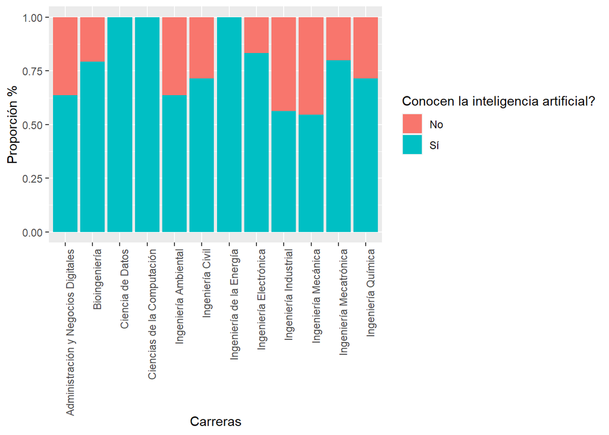

```r
BD %>%
  ggplot(aes(x = Carrera, fill = Conoce)) +
  geom_bar(position = "fill") +
  labs(x = "Carreras", y = "Proporción %", fill = "Conocen la inteligencia artificial?") +
  theme(axis.text.x = element_text(angle = 90, hjust = 1))
```

Se puede apreciar que las carreras que conocen más las IAs son las carreras que tienen más relación a esta, es decir, “Ciencia de datos” y “Ciencia de la computación”, destacando también “Ingeniería de la Energía (debido a que sólo contamos con una persona de esta carrera registrada en nuestra encuesta).

### Ahora analizamos la variable “Tipo_Curso” con “Utilidad”, es decir, graficaremos si en el tipo de cursos que usan los estudiantes UTEC les da una respuesta útil:

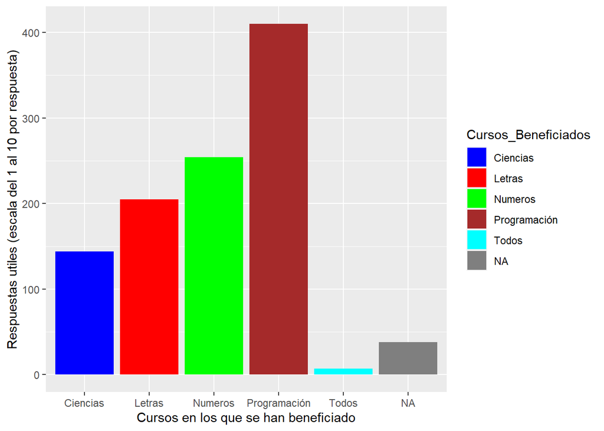

```r
BD %>%
  ggplot(aes(x = Cursos_Beneficiados, y = Utilidad, fill=Cursos_Beneficiados)) +
  geom_col() +
  scale_fill_manual(values = c("blue", "red", "green", "brown", "cyan", "black")) +
  labs(x = "Cursos en los que se han beneficiado", y = "Respuestas utiles (escala del 1 al 10 por respuesta)")
```

Se puede apreciar que Programación es el curso que destaca en respuesta útiles y que la mayoría de los estudiantes usa IA en Programación, seguido por números, en tercera posición Letras y por último Ciencias. Tiene sentido que en ciencias no de tantas respuestas útiles, esto es debido a que este tipo de cursos son más complejos para analizar. Sólo algunos no usan la IA en ningún curso, y muy pocos usan la IA en todos.

#### Ahora analizaremos la variable “Ciclo” con la variable “Preocupación_IA”, esto con la intención de obtener el pensamiento futuro con respecto a la IA de cada estudiante UTEC según su ciclo:

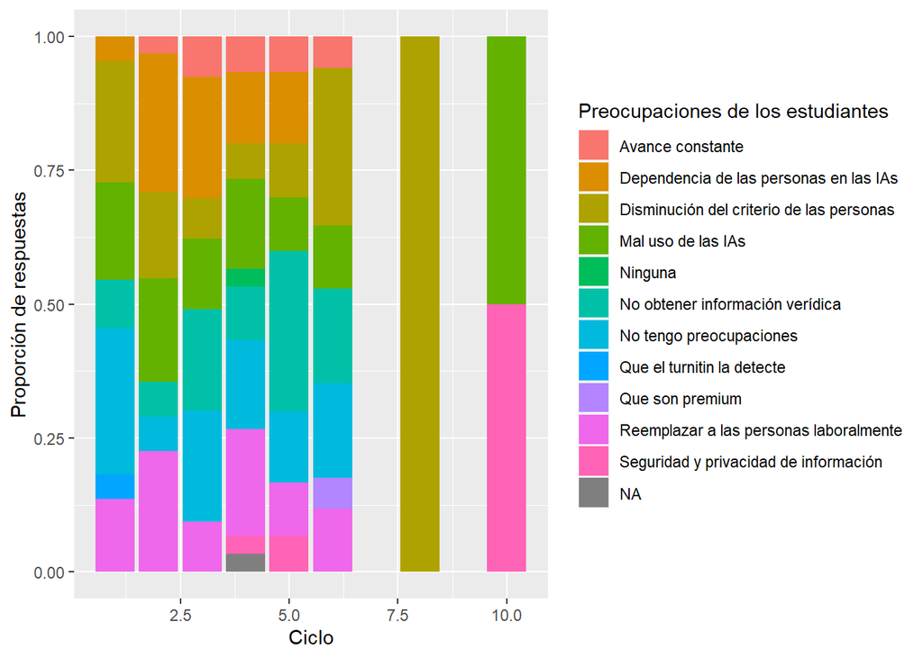

```r
BD %>%
  ggplot(aes(x = Ciclo, fill = Preocupacion)) +
  geom_bar(position = "fill") +
  labs(x = "Ciclo", y = "Proporción de respuestas", fill = "Preocupaciones de los estudiantes")
```